# Nonlinear Models in brms

From curve fitting to statistical modeling

Benjamin Rosenbaum

## About me

### Benjamin Rosenbaum

- Computational Ecology
- Statistical modeling
- Statistical consulting & teaching

[Google Scholar](https://scholar.google.com/citations?user=_OHiB_AAAAAJ&hl=en) | [GitHub](https://github.com/benjamin-rosenbaum) | [Bluesky](https://bsky.app/profile/benrosenbaum.bsky.social)

[figure not shown]

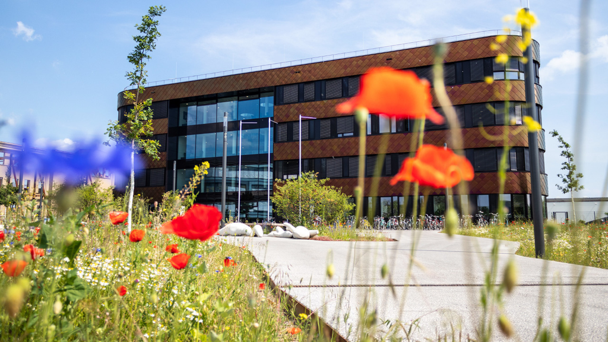

Source: Stefan Bernhardt / iDiv

## Scenario

- You have some interesting data
- You want to analyze it with a nonlinear model  
  (first principles / theory / literature / … )
- Maybe you have some treatment variables, too
- You realize this does not work with `glm` or `lme4`

## This course

- … is a brief & dense introduction
- … will get you started with nonlinear statistical modeling
- … has all materials available on GitHub
- … can be followed by coding with `Nonlinear_stats.R`

## Questionnaire

Who has already worked with

- Linear regression & ANOVA ?
- Generalized linear models ?
- Bayesian statistics ?

## Outline

**1. Statistical modeling & Bayesian inference**

2. Fitting nonlinear curves with `brms`
3. Continuous & categorical treatment variables
4. Exercises

## Example dataset

- Feeding experiments predator-prey
- Gradient of prey abundance
- Measure density-dependent feeding rates

[figure not shown]

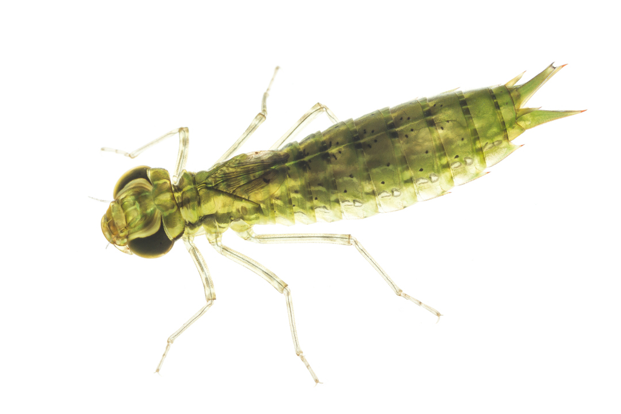

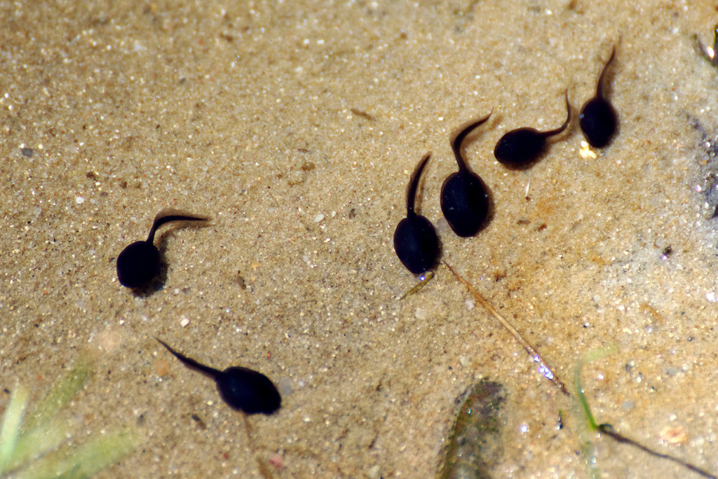

Source: https://commons.wikimedia.org/wiki/File:20200509_Kijanki_stawy_pod_Borz%C4%99cinem_1244_1710.jpg  
CC BY-SA 4.0

## Example dataset

- Feeding experiments predator-prey
- Gradient of prey abundance
- Measure density-dependent feeding rates

[figure not shown]

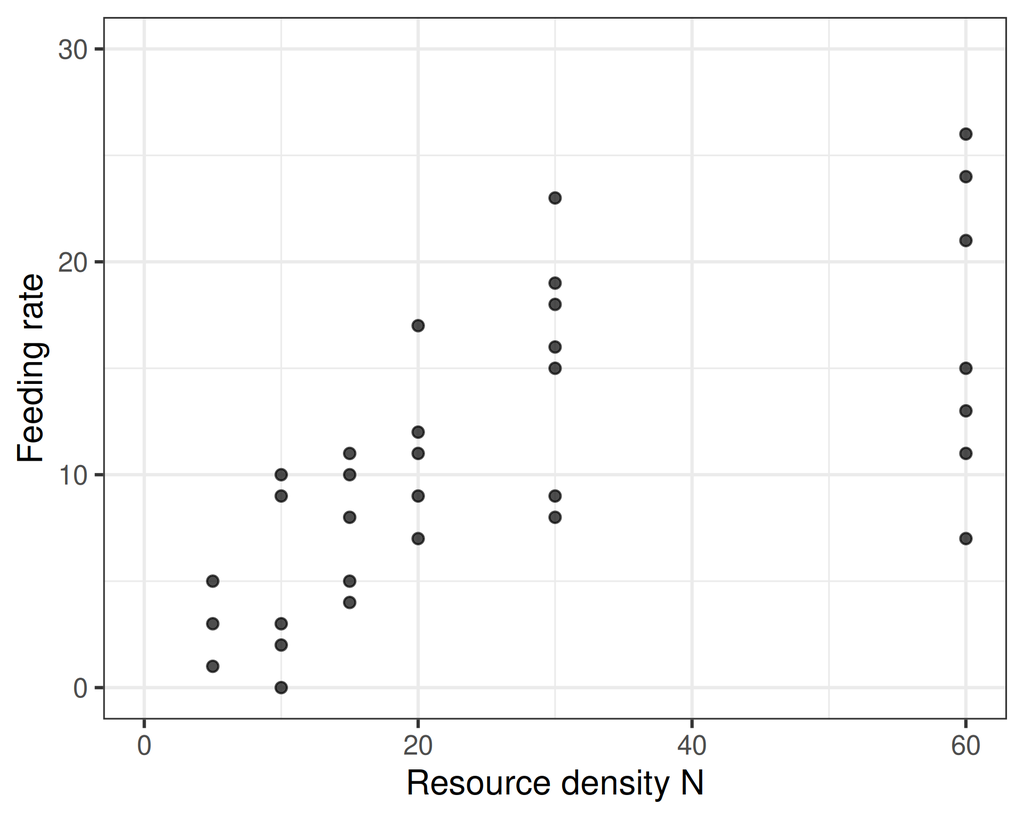

## Anatomy of a statistical model

**Deterministic part**

Predicts the mean response:
$${{\textcolor{black}{\mu(x)}}} = \beta_0+\beta_1\cdot x \vphantom{\frac{F_\max\cdot x}{N_\text{half}+x}}$$

**Stochastic part**

How observations scatter around mean:
$$y \sim \text{ Normal} {(} \mu(x), {\sigma )}$$

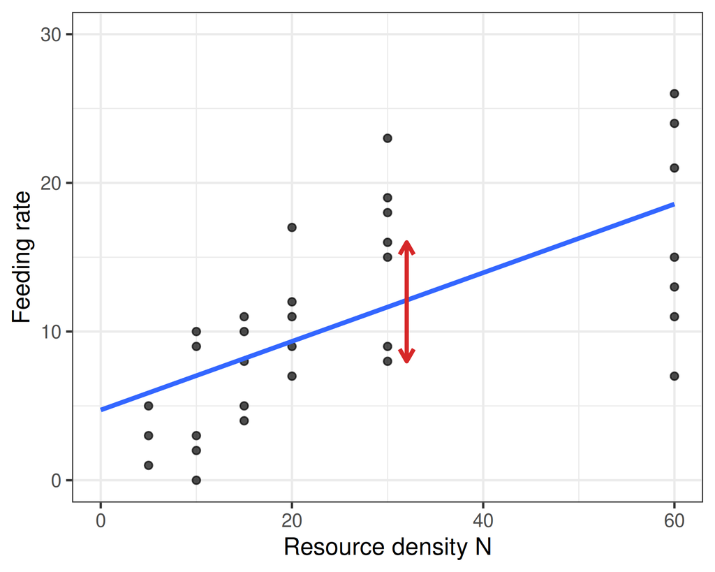

## What is a nonlinear model?

$$\mu(x) = {{\beta_0}}+{{\beta_1}}\cdot{x}$$

$$y \sim \operatorname{Normal} \left( \mu(x),\sigma \right)$$

- Linear in predictor $x$ (line)
- Linear in parameters $\beta$
- Normal distribution

**→ Linear regression**

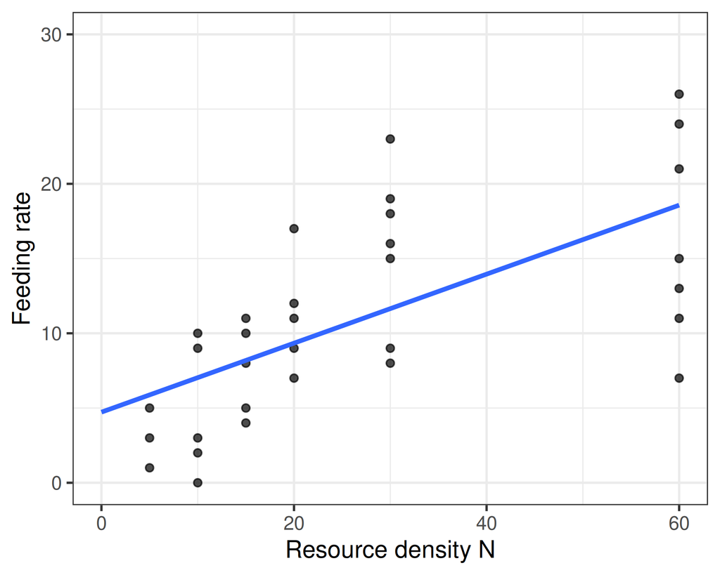

## What is a nonlinear model?

$$\mu(x) = {{\beta_0}}+{{\beta_1}}\cdot{x} + {\beta_2} \cdot x^2$$

$$y \sim \operatorname{Normal} \left( \mu(x),\sigma \right)$$

- Nonlinear in predictor $x$ (curve)
- Linear in parameters $\beta$
- Normal distribution

**→ Linear regression**

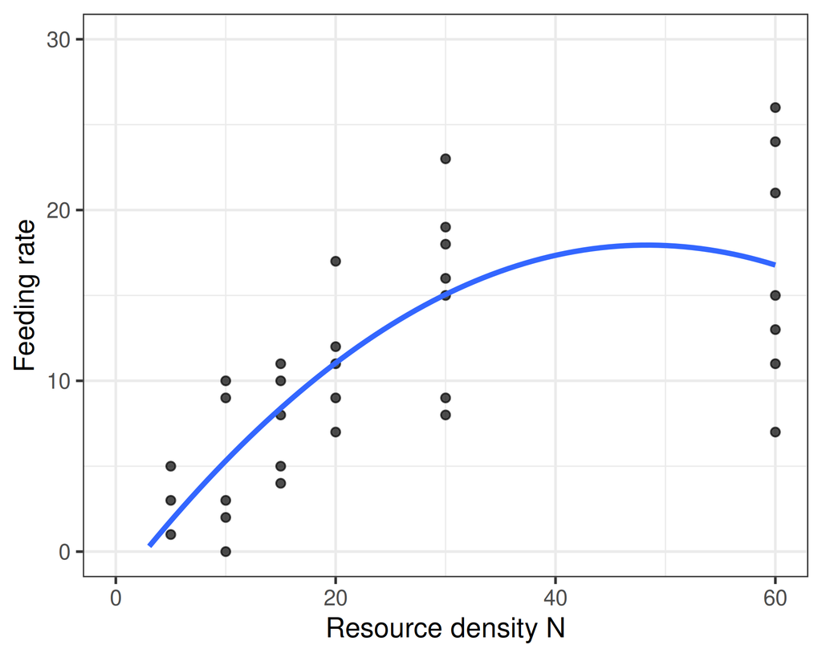

## What is a nonlinear model?

$$\log(\mu(x)) = {{\beta_0}}+{{\beta_1}}\cdot{x} + {\beta_2} \cdot x^2$$

$$y \sim \operatorname{Poisson} \left( \mu(x) \right)$$

- Nonlinear link function on linear model
- Linear in parameters $\beta$
- Non-normal distribution family

**→ Generalized linear model (GLM)**

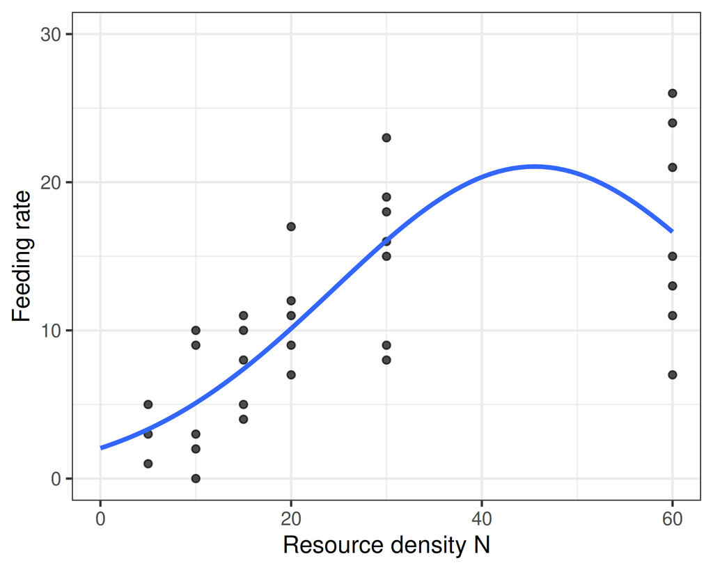

## What is a nonlinear model?

$$\mu(x) = \exp\left( {{\beta_0}}+{{\beta_1}}\cdot{x} + {\beta_2} \cdot x^2 \right)$$

$$y \sim \operatorname{Poisson} \left( \mu(x) \right)$$

- Nonlinear link function on linear model
- Linear in parameters $\beta$
- Non-normal distribution family

**→ Generalized linear model (GLM)**

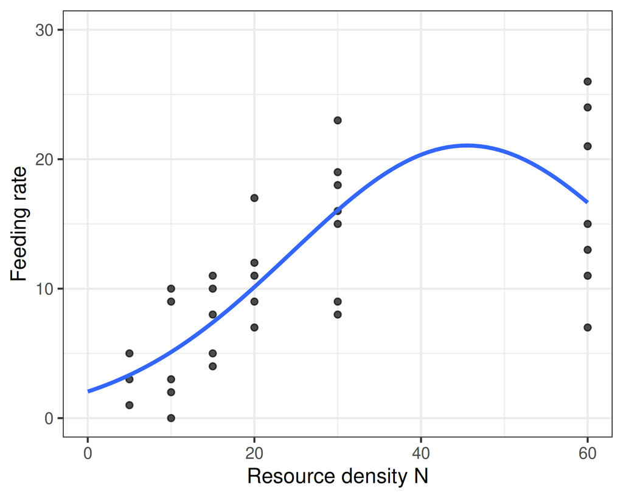

## What is a nonlinear model?

$$\mu(x) = \frac{F_\max\cdot x}{N_\text{half}+x}$$

$$y \sim \operatorname{Poisson} \left( \mu(x) \right)$$

- Nonlinear in predictor $x$
- **Nonlinear in parameters** ${ F_\max, N_\text{half} }$
- (Non-normal distribution family)

**→ Nonlinear model**

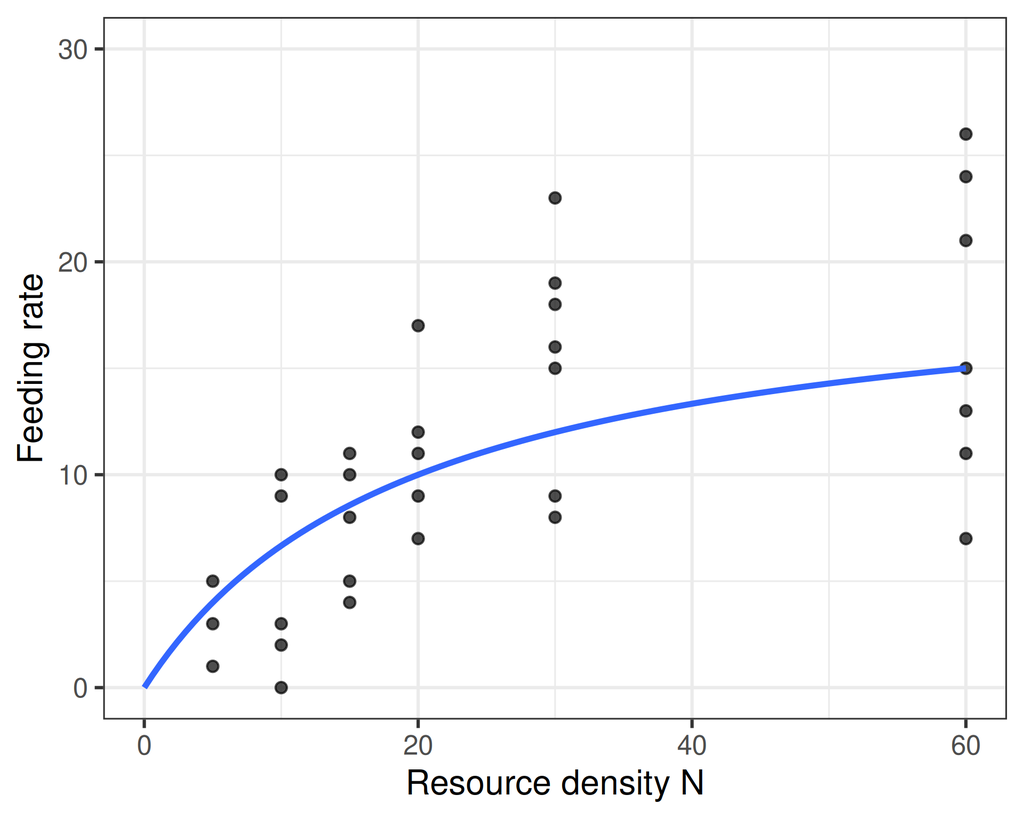

## Nonlinear models in Ecology

- Describe a process
- Mathematical model from theory  
  “By dividing up total time into a predator’s search time and time for prey handling, after some re-arrangement I finally arrive with that formula.”
- Or, phenomenological model  
  “I want a function linear in (0,0), but it should have an asymptote defined by the predator’s maximum feeding rate.”
- Parameters have a meaning
- We want to test hypotheses related to predictions,  
  or related to parameters directly

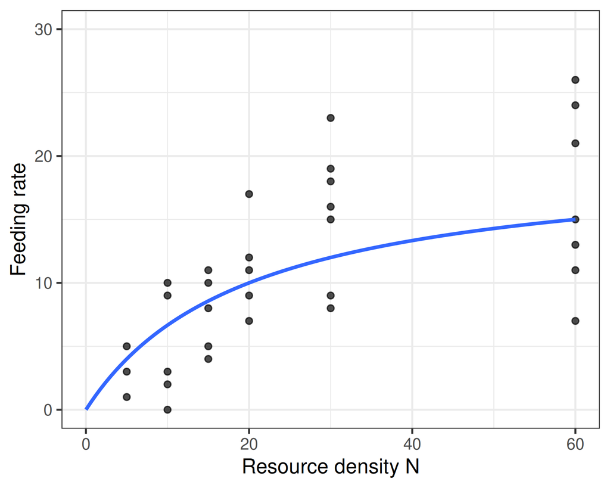

## Nonlinear models

### Functional response

e.g.

$$\text{Feeding} = \frac{\textcolor{var(--highlight-high-border)}{\boldsymbol{F_\max}}\cdot N}{\textcolor{var(--highlight-high-border)}{\boldsymbol{N_\text{\bf half}}}+N}$$
Also describes Michaelis-Menten enzyme kinetics

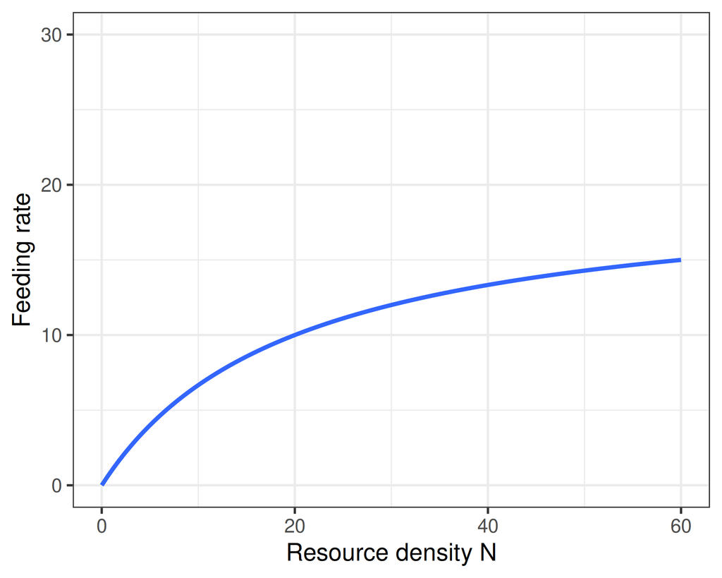

## Nonlinear models

### Thermal performance

e.g. Brière model

$$\text{Rate} = \textcolor{var(--highlight-high-border)}{\boldsymbol{\beta_0}}\cdot{T}\cdot\left({T}-\textcolor{var(--highlight-high-border)}{\boldsymbol{T_\min}}\right)\cdot\sqrt{\textcolor{var(--highlight-high-border)}{\boldsymbol{T_\max}}-{T}}$$
growth, photosynthesis, or respiration rates

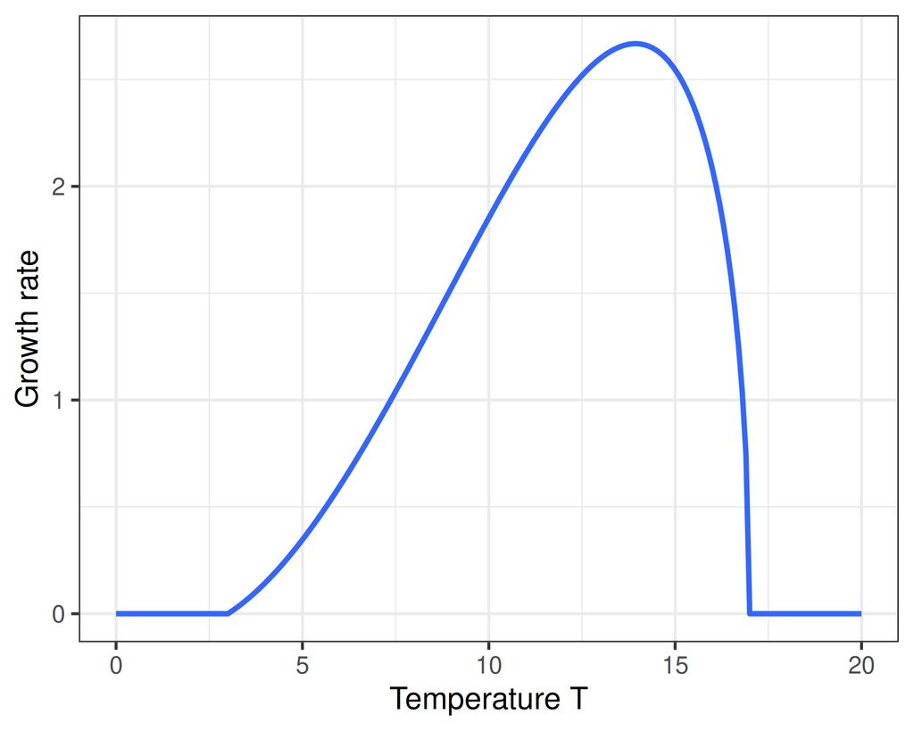

## Nonlinear models

### Population growth

e.g. Logistic growth model

$$N(t) = \frac{\textcolor{var(--highlight-high-border)}{\boldsymbol{K}}}{1+\left( \frac{\textcolor{var(--highlight-high-border)}{\boldsymbol{K}}}{\textcolor{var(--highlight-high-border)}{\boldsymbol{N_0}}}-1 \right)e^{-\textcolor{var(--highlight-high-border)}{\boldsymbol{r}} t }}$$

Is analytical solution of the dynamical system
$$\begin{align}
\frac{dN(t)}{dt}&=rN\left(1-\frac{N}{K}\right)\\
N(0)&=N_0
\end{align}$$

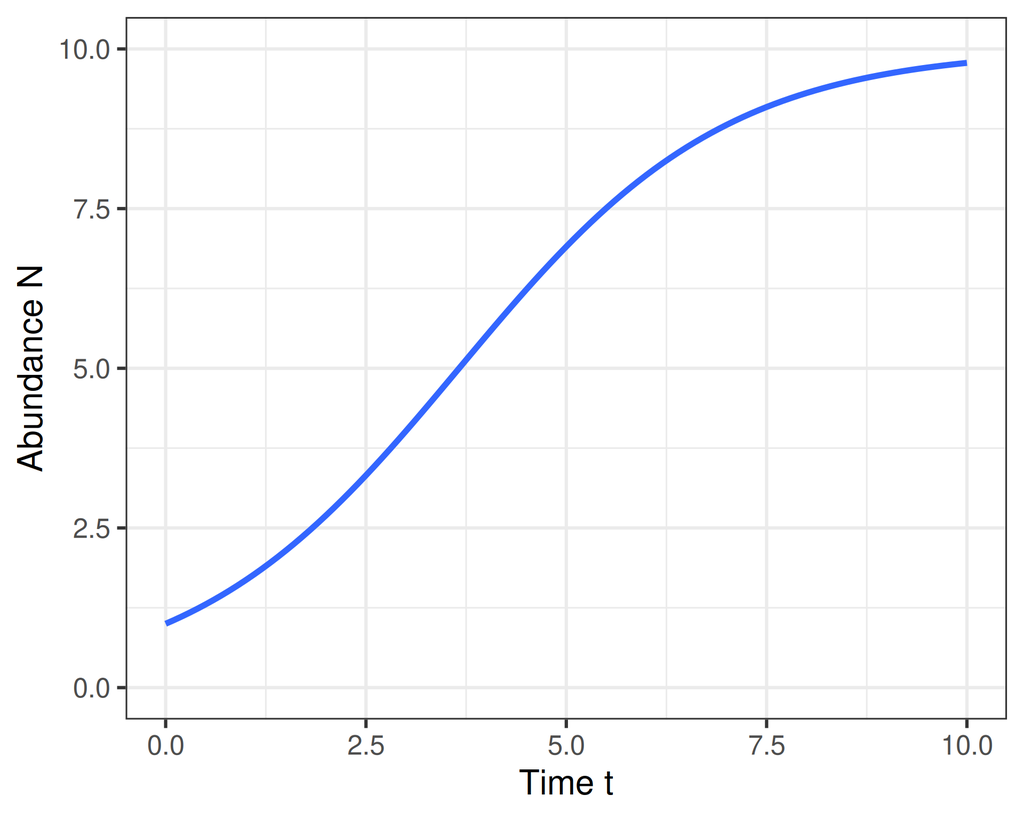

## Nonlinear models

### Individual growth

e.g. von Bertalanffy growth function

$$\text{Length} = \textcolor{var(--highlight-high-border)}{\boldsymbol{L_\max}}\left(1-e^{- \textcolor{var(--highlight-high-border)}{\boldsymbol{r}} \left(\text{Age}-\textcolor{var(--highlight-high-border)}{\boldsymbol{t_0}}\right)} \right)$$

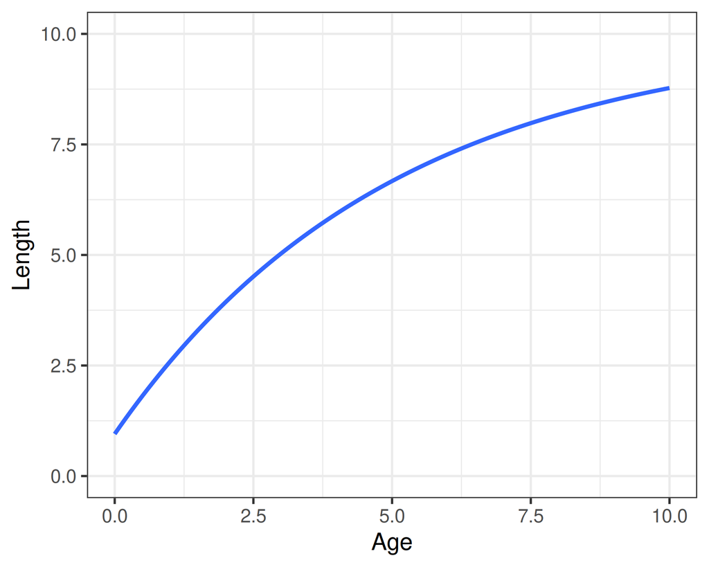

## Maximum likelihood estimation

$$\begin{align}
L(\theta) &= P(y|\theta) \\ \vphantom{\prod_{i=1:n}^n} &= \prod_{i=1:n}P\left(\ y_i\ |\ \mu\left(x_i\right)\ \right)
\end{align}$$

- Likelihood function $L(\theta )$ calculates probability  
  of observed data $y$ for a parameter value $\theta$
- Given the observed data, which parameter values  
  are most likely?
- Find *point estimate* $\theta^*$ that maximizes $L(\theta)$

**But:** $L(\theta)$ is **not** a probability density function for $\theta$

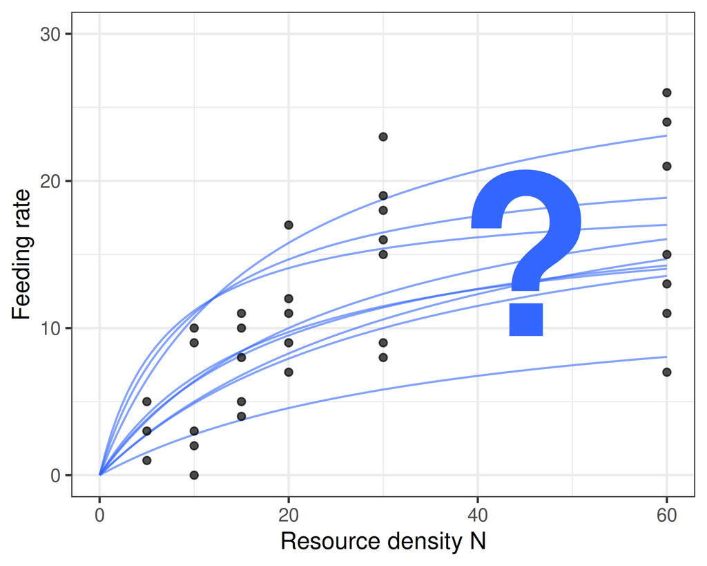

## Bayesian statistics

$$P(\theta|y) = \frac{P(y|\theta) \cdot P(\theta)}{P(y)}$$

What we need:

- **Likelihood** $P(y|\theta)$:  
  connects model predictions with data
- **Prior** $P(\theta)$:  
  prior beliefs on parameter range

What we get

- **Posterior** $P(\theta|y)$:  
  probability distribution of parameters

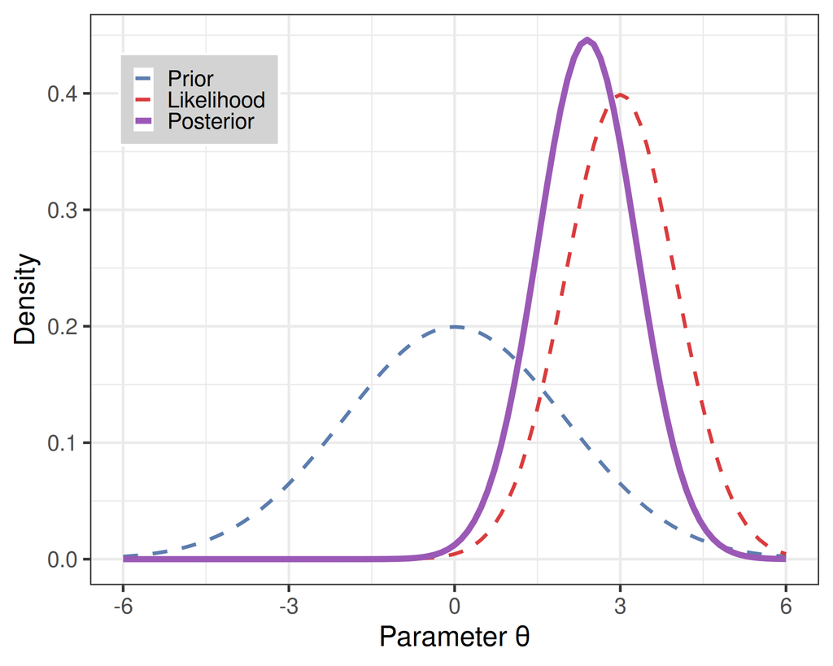

## Bayesian statistics

$$P(\theta|y) = \frac{P(y|\theta) \cdot P(\theta)}{P(y)}$$

What we need:

- **Likelihood** $P(y|\theta)$:  
  connects model predictions with data
- **Prior** $P(\theta)$:  
  prior beliefs on parameter range

What we get

- **Posterior** $P(\theta|y)$:  
  probability distribution of parameters

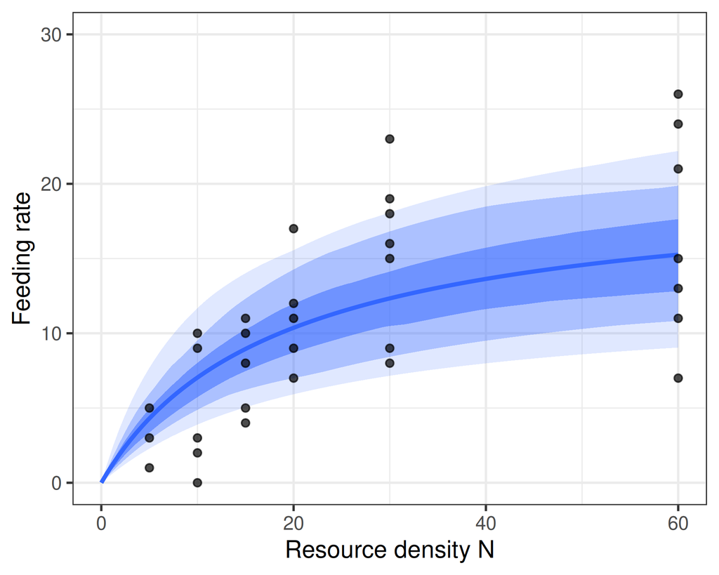

## MCMC

$$P(\theta|y) = \frac{P(y|\theta) \cdot P(\theta)}{P(y)}$$

- Cannot compute $P(\theta|y)$ mathematically:  
  $P(y)$ is a constant, but includes nasty integral

$$P(\theta|y) \sim P(y|\theta) \cdot P(\theta)$$

- Posterior is proportional to Likelihood x Prior
- MCMC can iteratively draw random samples  
  $s_1,s_2,\dots,s_{5000}$
- Compute empirical mean, sdev, CI etc from sample

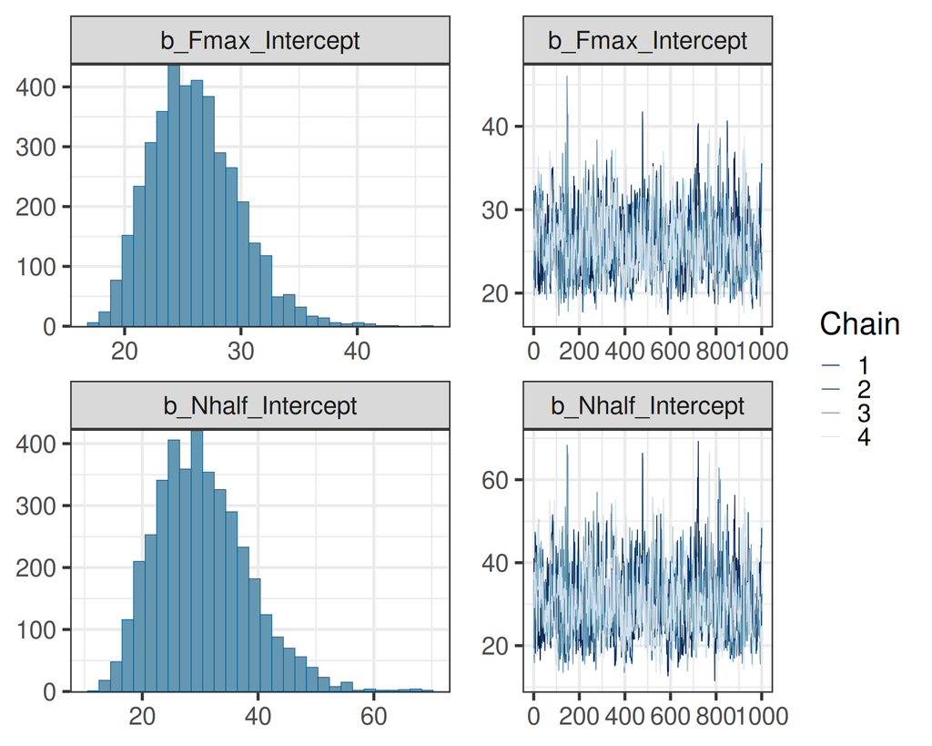

## Why Bayesian?

- MCMC works with linear and nonlinear models
- Get true probability distribution (uncertainty) of
  - Model parameters
  - Predictions
  - Means, contrasts, etc.
- **Direct inference** instead of Null Hypothesis Significance Testing
- Highly flexible & reliable with **random effects** structures, too

[figure not shown]

## Methods & Software

**`nls` / `nlme` (maximum likelihood)**

- ✅ treatment variables & random effects
- ❌ Gaussian only
- ❌ no parameter constraining

**`bbmle` package (maximum likelihood)**

- ✅ more flexible
- ❌ write model code manually
- ❌ write predictions, comparisons etc manually

**`JAGS` / `Nimble` / `Stan` (MCMC)**

- ✅ full flexibility
- ❌ write model code manually
- ❌ write predictions, comparisons etc manually

**`brms` package**

- ✅ best of both worlds:
  1. easy & flexible model specification
  2. MCMC under the hood
- ✅ automated tools for model analysis
1. Statistical modeling & Bayesian inference
2. **Fitting nonlinear curves with `brms`**
3. Continuous & categorical treatment variables
4. Exercises

## The `brms` package

**B**ayesian **R**egression **M**odels using **S**tan

- Lets you define models conveniently in `lme4`-syntax
- Translates models to `Stan` & runs MCMC
- **Huge** variety of model classes:
  - Classic LM, GLM, LMM, GLMM. Even GAM !
  - Correlation structures: temporal, spatial, phylogenetic
  - Many distribution families
  - Multivariate models
- Tools for plotting, model checking, predictions, hypothesis testing
- Compatible with packages like `emmeans`, `marginaleffects`, `DHARMa`

[figure not shown]

## Linear regression

```r
formula = bf(Feeding ~ N)

priors  = prior(normal(0,1), class="b")

fit.1   = brm(formula,
              prior = priors,
              data = df)

summary(fit.1)
```

```
 Family: gaussian
  Links: mu = identity
Formula: Feeding ~ N
   Data: df (Number of observations: 32)
  Draws: 4 chains, each with iter = 2000; warmup = 1000; thin = 1;
         total post-warmup draws = 4000

Regression Coefficients:
          Estimate Est.Error l-95% CI u-95% CI Rhat Bulk_ESS Tail_ESS
Intercept     4.75      1.70     1.43     8.05 1.00     4302     2969
N             0.23      0.05     0.13     0.33 1.00     4246     2994

Further Distributional Parameters:
      Estimate Est.Error l-95% CI u-95% CI Rhat Bulk_ESS Tail_ESS
sigma     5.48      0.72     4.27     7.05 1.00     3550     2806

Draws were sampled using sample(hmc). For each parameter, Bulk_ESS
and Tail_ESS are effective sample size measures, and Rhat is the potential
scale reduction factor on split chains (at convergence, Rhat = 1).
```

## Linear regression

```r
formula = bf(Feeding ~ N)

priors  = prior(normal(0,1), class="b")

fit.1   = brm(formula,
              prior = priors,
              data = df)

summary(fit.1)
```

```
 Family: gaussian
  Links: mu = identity
Formula: Feeding ~ N
   Data: df (Number of observations: 32)
  Draws: 4 chains, each with iter = 2000; warmup = 1000; thin = 1;
         total post-warmup draws = 4000

Regression Coefficients:
          Estimate Est.Error l-95% CI u-95% CI Rhat Bulk_ESS Tail_ESS
Intercept     4.75      1.70     1.43     8.05 1.00     4302     2969
N             0.23      0.05     0.13     0.33 1.00     4246     2994

Further Distributional Parameters:
      Estimate Est.Error l-95% CI u-95% CI Rhat Bulk_ESS Tail_ESS
sigma     5.48      0.72     4.27     7.05 1.00     3550     2806

Draws were sampled using sample(hmc). For each parameter, Bulk_ESS
and Tail_ESS are effective sample size measures, and Rhat is the potential
scale reduction factor on split chains (at convergence, Rhat = 1).
```

#### Check convergence

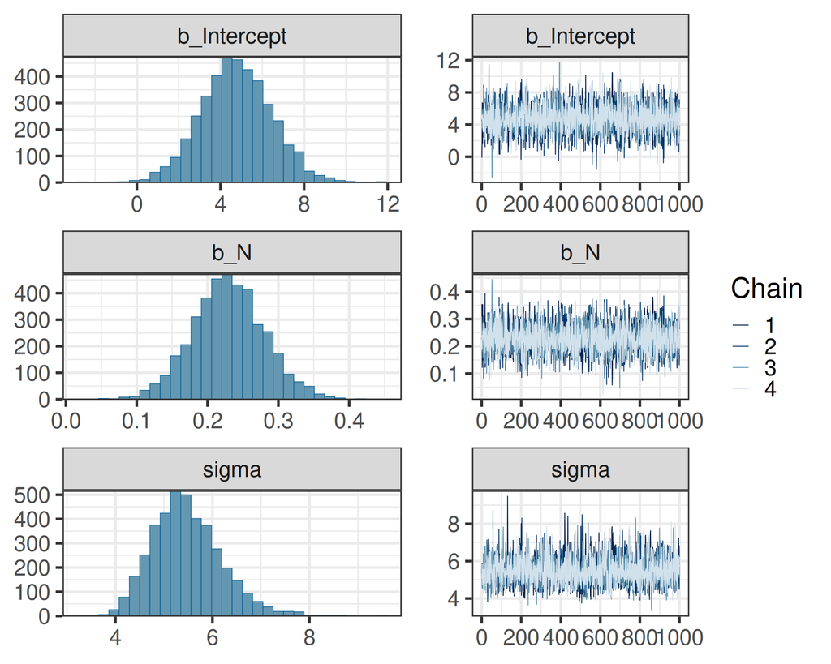

```r
plot(fit.1)
```

- `Rhat<1.01` ?
- Traceplots look like fuzzy caterpillars ?

## Linear regression

```r
formula = bf(Feeding ~ N)

priors  = prior(normal(0,1), class="b")

fit.1   = brm(formula,
              prior = priors,
              data = df)

summary(fit.1)
```

```
 Family: gaussian
  Links: mu = identity
Formula: Feeding ~ N
   Data: df (Number of observations: 32)
  Draws: 4 chains, each with iter = 2000; warmup = 1000; thin = 1;
         total post-warmup draws = 4000

Regression Coefficients:
          Estimate Est.Error l-95% CI u-95% CI Rhat Bulk_ESS Tail_ESS
Intercept     4.75      1.70     1.43     8.05 1.00     4302     2969
N             0.23      0.05     0.13     0.33 1.00     4246     2994

Further Distributional Parameters:
      Estimate Est.Error l-95% CI u-95% CI Rhat Bulk_ESS Tail_ESS
sigma     5.48      0.72     4.27     7.05 1.00     3550     2806

Draws were sampled using sample(hmc). For each parameter, Bulk_ESS
and Tail_ESS are effective sample size measures, and Rhat is the potential
scale reduction factor on split chains (at convergence, Rhat = 1).
```

#### Check model fit

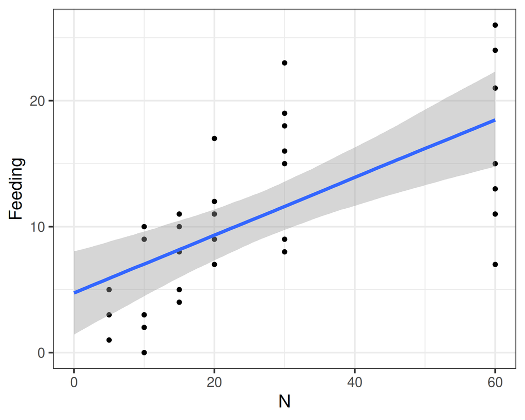

```r
plot(conditional_effects(fit.1),
     points=TRUE)
```

- Credible intervals for deterministic part  
  $\mu(N)$

## Linear regression

```r
formula = bf(Feeding ~ N)

priors  = prior(normal(0,1), class="b")

fit.1   = brm(formula,
              prior = priors,
              data = df)

summary(fit.1)
```

```
 Family: gaussian
  Links: mu = identity
Formula: Feeding ~ N
   Data: df (Number of observations: 32)
  Draws: 4 chains, each with iter = 2000; warmup = 1000; thin = 1;
         total post-warmup draws = 4000

Regression Coefficients:
          Estimate Est.Error l-95% CI u-95% CI Rhat Bulk_ESS Tail_ESS
Intercept     4.75      1.70     1.43     8.05 1.00     4302     2969
N             0.23      0.05     0.13     0.33 1.00     4246     2994

Further Distributional Parameters:
      Estimate Est.Error l-95% CI u-95% CI Rhat Bulk_ESS Tail_ESS
sigma     5.48      0.72     4.27     7.05 1.00     3550     2806

Draws were sampled using sample(hmc). For each parameter, Bulk_ESS
and Tail_ESS are effective sample size measures, and Rhat is the potential
scale reduction factor on split chains (at convergence, Rhat = 1).
```

#### Check model fit

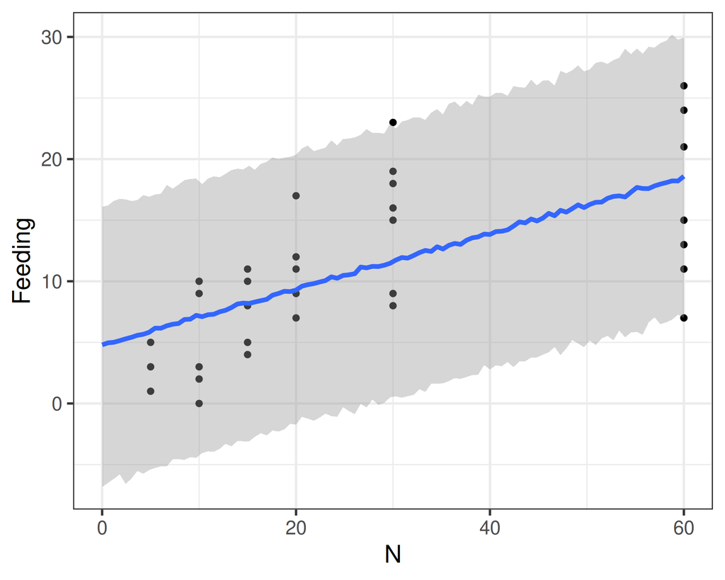

```r
plot(conditional_effects(fit.1,
                         method="posterior_predict"),
     points=TRUE)
```

- Prediction intervals det. & stoch. part  
  $\text{Normal}(\mu(N),\sigma)$

## Linear regression

```r
formula = bf(Feeding ~ N)

priors  = prior(normal(0,1), class="b")

fit.1   = brm(formula,
              prior = priors,
              data = df)

summary(fit.1)
```

```
 Family: gaussian
  Links: mu = identity
Formula: Feeding ~ N
   Data: df (Number of observations: 32)
  Draws: 4 chains, each with iter = 2000; warmup = 1000; thin = 1;
         total post-warmup draws = 4000

Regression Coefficients:
          Estimate Est.Error l-95% CI u-95% CI Rhat Bulk_ESS Tail_ESS
Intercept     4.75      1.70     1.43     8.05 1.00     4302     2969
N             0.23      0.05     0.13     0.33 1.00     4246     2994

Further Distributional Parameters:
      Estimate Est.Error l-95% CI u-95% CI Rhat Bulk_ESS Tail_ESS
sigma     5.48      0.72     4.27     7.05 1.00     3550     2806

Draws were sampled using sample(hmc). For each parameter, Bulk_ESS
and Tail_ESS are effective sample size measures, and Rhat is the potential
scale reduction factor on split chains (at convergence, Rhat = 1).
```

#### Check model fit

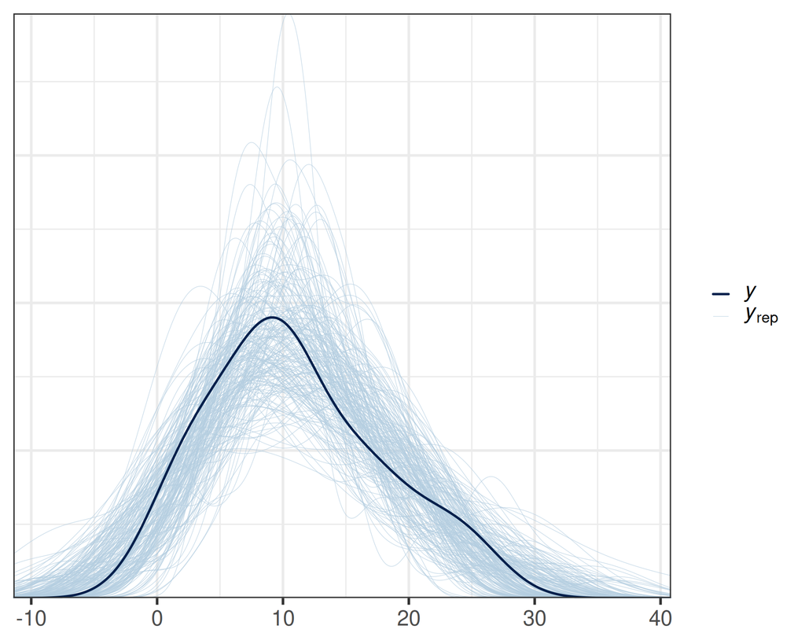

```r
pp_check(fit.1, ndraws=200)
```

- Compare observed vs. predicted data

## Nonlinear model

#### Deterministic part: model formula

$\mu(N) = \frac{\textcolor{#d62728}{\boldsymbol{F_\max}}\cdot N}{\textcolor{#d62728}{\boldsymbol{N_\text{\bf half}}}+N}$

```r
formula = bf(Feeding ~ fmax*N/(nhalf+N),
             fmax ~ 1,
             nhalf ~ 1,
             nl = TRUE)
```

- Write out formula as R-code  
  wrapped in `bf(..., nl=TRUE)`
- Original variable names: `N`, `Feeding`
- Custom parameter names: `fmax`, `nhalf`
- Parameters do not depend on additional predictors: `fmax~1, nhalf~1`

## Nonlinear model

#### Priors

$\mu(N)= \frac{\textcolor{#d62728}{\boldsymbol{F_\max}}\cdot N}{\textcolor{#d62728}{\boldsymbol{N_\text{\bf half}}}+N}$

```r
priors = c(
  prior(normal(20,5), nlpar="fmax", lb=0),
  prior(normal(15,5), nlpar="nhalf", lb=0)
)
```

- Specify (at least) weakly informative priors for every parameter
- If necessary, enforce positiveness with `lb=0`
- If you are unsure, use prior predictive checks `brm(..., sample_prior = "only")`

## Nonlinear model

#### Stochastic part

$\text{Feeding}_i \sim \operatorname{Poisson}\left( \mu\left( N_i\right)\right)$

```r
brm(..., family = poisson(link="identity"))
```

- Distribution of response values around mean prediction curve
- Is response
  - unbounded or bounded, e.g. > 0 ?
  - continuous or integer ?
  - overdispersed ?
- If nonlinear model predicts on correct scale,  
  no link function required: `link="identity"`

## Nonlinear model

```r
formula = bf(Feeding ~ fmax*N/(nhalf+N),
             fmax ~ 1,
             nhalf ~ 1,
             nl = TRUE)
priors  = c(
  prior(normal(20,5), nlpar="fmax", lb=0),
  prior(normal(15,5), nlpar="nhalf", lb=0)
)
fit.2   = brm(formula,
              prior = priors,
              family = poisson(link="identity"),
              data = df)

summary(fit.2)
```

```
 Family: poisson
  Links: mu = identity
Formula: Feeding ~ fmax * N/(nhalf + N)
         fmax ~ 1
         nhalf ~ 1
   Data: df (Number of observations: 32)
  Draws: 4 chains, each with iter = 2000; warmup = 1000; thin = 1;
         total post-warmup draws = 4000

Regression Coefficients:
                Estimate Est.Error l-95% CI u-95% CI Rhat Bulk_ESS Tail_ESS
fmax_Intercept     22.21      1.89    18.60    26.03 1.00     1049     1121
nhalf_Intercept    21.74      3.52    15.11    28.71 1.00     1065     1035

Draws were sampled using sample(hmc). For each parameter, Bulk_ESS
and Tail_ESS are effective sample size measures, and Rhat is the potential
scale reduction factor on split chains (at convergence, Rhat = 1).
```

## Nonlinear model

```r
formula = bf(Feeding ~ fmax*N/(nhalf+N),
             fmax ~ 1,
             nhalf ~ 1,
             nl = TRUE)
priors  = c(
  prior(normal(20,5), nlpar="fmax", lb=0),
  prior(normal(15,5), nlpar="nhalf", lb=0)
)
fit.2   = brm(formula,
              prior = priors,
              family = poisson(link="identity"),
              data = df)

summary(fit.2)
```

```
 Family: poisson
  Links: mu = identity
Formula: Feeding ~ fmax * N/(nhalf + N)
         fmax ~ 1
         nhalf ~ 1
   Data: df (Number of observations: 32)
  Draws: 4 chains, each with iter = 2000; warmup = 1000; thin = 1;
         total post-warmup draws = 4000

Regression Coefficients:
                Estimate Est.Error l-95% CI u-95% CI Rhat Bulk_ESS Tail_ESS
fmax_Intercept     22.21      1.89    18.60    26.03 1.00     1049     1121
nhalf_Intercept    21.74      3.52    15.11    28.71 1.00     1065     1035

Draws were sampled using sample(hmc). For each parameter, Bulk_ESS
and Tail_ESS are effective sample size measures, and Rhat is the potential
scale reduction factor on split chains (at convergence, Rhat = 1).
```

#### Check convergence

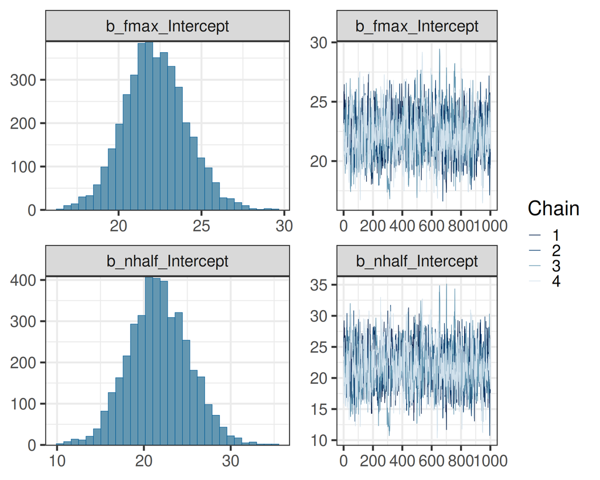

```r
plot(fit.2)
```

- `Rhat<1.01` ?
- Traceplots look like fuzzy caterpillars ?

## Nonlinear model

```r
formula = bf(Feeding ~ fmax*N/(nhalf+N),
             fmax ~ 1,
             nhalf ~ 1,
             nl = TRUE)
priors  = c(
  prior(normal(20,5), nlpar="fmax", lb=0),
  prior(normal(15,5), nlpar="nhalf", lb=0)
)
fit.2   = brm(formula,
              prior = priors,
              family = poisson(link="identity"),
              data = df)

summary(fit.2)
```

```
 Family: poisson
  Links: mu = identity
Formula: Feeding ~ fmax * N/(nhalf + N)
         fmax ~ 1
         nhalf ~ 1
   Data: df (Number of observations: 32)
  Draws: 4 chains, each with iter = 2000; warmup = 1000; thin = 1;
         total post-warmup draws = 4000

Regression Coefficients:
                Estimate Est.Error l-95% CI u-95% CI Rhat Bulk_ESS Tail_ESS
fmax_Intercept     22.21      1.89    18.60    26.03 1.00     1049     1121
nhalf_Intercept    21.74      3.52    15.11    28.71 1.00     1065     1035

Draws were sampled using sample(hmc). For each parameter, Bulk_ESS
and Tail_ESS are effective sample size measures, and Rhat is the potential
scale reduction factor on split chains (at convergence, Rhat = 1).
```

#### Check model fit

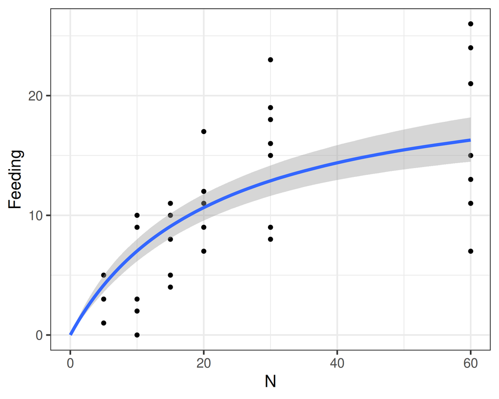

```r
plot(conditional_effects(fit.2),
     points=TRUE)
```

- Credible intervals for deterministic part  
  $\mu(N)$

## Nonlinear model

```r
formula = bf(Feeding ~ fmax*N/(nhalf+N),
             fmax ~ 1,
             nhalf ~ 1,
             nl = TRUE)
priors  = c(
  prior(normal(20,5), nlpar="fmax", lb=0),
  prior(normal(15,5), nlpar="nhalf", lb=0)
)
fit.2   = brm(formula,
              prior = priors,
              family = poisson(link="identity"),
              data = df)

summary(fit.2)
```

```
 Family: poisson
  Links: mu = identity
Formula: Feeding ~ fmax * N/(nhalf + N)
         fmax ~ 1
         nhalf ~ 1
   Data: df (Number of observations: 32)
  Draws: 4 chains, each with iter = 2000; warmup = 1000; thin = 1;
         total post-warmup draws = 4000

Regression Coefficients:
                Estimate Est.Error l-95% CI u-95% CI Rhat Bulk_ESS Tail_ESS
fmax_Intercept     22.21      1.89    18.60    26.03 1.00     1049     1121
nhalf_Intercept    21.74      3.52    15.11    28.71 1.00     1065     1035

Draws were sampled using sample(hmc). For each parameter, Bulk_ESS
and Tail_ESS are effective sample size measures, and Rhat is the potential
scale reduction factor on split chains (at convergence, Rhat = 1).
```